# HUK Case Study - EDA

Author

Chris-Gabriel Islam

Published

March 11, 2025

# Init

```r
rm(list = ls())
knitr::opts_chunk$set(echo = TRUE)
library(ggplot2) # for data visualization
library(GGally) # for correlation analysis
library(dplyr) # for data manipulation
library(foreign) # to load arff data
library(DescTools) # for winsorizing
```

# Read data

```r
data_freq <- read.arff(here::here("data", "raw", "freMTPL2freq.arff"))
data_sev <- read.arff(here::here("data", "raw", "freMTPL2sev.arff"))
```

# Checking data integrity

```r
# check for missing values
sum(is.na(data_freq))
```

```
[1] 0
```

```r
sum(is.na(data_sev))
```

```
[1] 0
```

```r
# check for data types
str(data_freq)
```

```
'data.frame':   678013 obs. of  12 variables:
 $ IDpol     : num  1 3 5 10 11 13 15 17 18 21 ...
 $ ClaimNb   : num  1 1 1 1 1 1 1 1 1 1 ...
 $ Exposure  : num  0.1 0.77 0.75 0.09 0.84 0.52 0.45 0.27 0.71 0.15 ...
 $ Area      : Factor w/ 6 levels "A","B","C","D",..: 4 4 2 2 2 5 5 3 3 2 ...
 $ VehPower  : num  5 5 6 7 7 6 6 7 7 7 ...
 $ VehAge    : num  0 0 2 0 0 2 2 0 0 0 ...
 $ DrivAge   : num  55 55 52 46 46 38 38 33 33 41 ...
 $ BonusMalus: num  50 50 50 50 50 50 50 68 68 50 ...
 $ VehBrand  : Factor w/ 11 levels "B1","B10","B11",..: 4 4 4 4 4 4 4 4 4 4 ...
 $ VehGas    : chr  "Regular" "Regular" "Diesel" "Diesel" ...
 $ Density   : num  1217 1217 54 76 76 ...
 $ Region    : Factor w/ 22 levels "R11","R21","R22",..: 18 18 3 15 15 8 8 20 20 12 ...
```

```r
str(data_sev)
```

```
'data.frame':   26639 obs. of  2 variables:
 $ IDpol      : num  1552 1010996 4024277 4007252 4046424 ...
 $ ClaimAmount: num  995 1128 1851 1204 1204 ...
```

```r
# check for duplicates
sum(duplicated(data_freq))
```

```
[1] 0
```

```r
sum(duplicated(data_sev))
```

```
[1] 255
```

The data seems to be integer since there are no missing values. The data types are also following the data record description. For some variables we do not know the unit of measurement. The severity data contains some duplicates which means that 255 clients have more than one claim. The frequency data does not contain any duplicates.

```r
# sum ClaimAmount per client (for later check)
data_sev_agg <- data_sev %>%
  group_by(IDpol) %>%
  summarise(ClaimAmount = sum(ClaimAmount), ClaimNb_sev = n())
# join the client information to the aggregated severity data
data_sev_agg_clinfo <- merge(data_freq, data_sev_agg, by = "IDpol")
# check if the frequency information is the same in both data sets
sum(data_sev_agg_clinfo$ClaimNb != data_sev_agg_clinfo$ClaimNb_sev)
```

```
[1] 1
```

```r
# remove the inconsistent observations
data_sev_agg_clinfo <- data_sev_agg_clinfo[data_sev_agg_clinfo$ClaimNb == data_sev_agg_clinfo$ClaimNb_sev, ]
data_sev_agg_clinfo$ClaimNb_sev <- NULL
# check that every observation has a unique policy ID
sum(duplicated(data_sev_agg_clinfo$IDpol))
```

```
[1] 0
```

For 7 clients we seem to miss client information. Furthermore, there is one client with a different number of claims in the frequency and severity data. We remove this inconsistency since we cannot ask the claims department for a correction.

# Descriptive Analysis

```r
# Summary statistics
summary(data_sev_agg_clinfo)
```

```
     IDpol            ClaimNb         Exposure       Area        VehPower
 Min.   :    139   Min.   : 1.00   Min.   :0.00274   A:3237   Min.   : 4.000
 1st Qu.:1082674   1st Qu.: 1.00   1st Qu.:0.45000   B:2524   1st Qu.: 5.000
 Median :2130093   Median : 1.00   Median :0.76000   C:6730   Median : 6.000
 Mean   :2262482   Mean   : 1.06   Mean   :0.69266   D:6042   Mean   : 6.469
 3rd Qu.:3178466   3rd Qu.: 1.00   3rd Qu.:1.00000   E:5697   3rd Qu.: 7.000
 Max.   :6113971   Max.   :16.00   Max.   :2.00000   F: 713   Max.   :15.000

     VehAge          DrivAge        BonusMalus        VehBrand
 Min.   : 0.000   Min.   :18.00   Min.   : 50.00   B1     :6509
 1st Qu.: 3.000   1st Qu.:34.00   1st Qu.: 50.00   B2     :6486
 Median : 7.000   Median :45.00   Median : 55.00   B12    :3826
 Mean   : 7.386   Mean   :45.14   Mean   : 64.93   B3     :2304
 3rd Qu.:11.000   3rd Qu.:54.00   3rd Qu.: 76.00   B5     :1580
 Max.   :99.000   Max.   :99.00   Max.   :228.00   B6     :1189
                                                   (Other):3049
    VehGas             Density          Region      ClaimAmount
 Length:24943       Min.   :    2   R24    :6262   Min.   :      1
 Class :character   1st Qu.:  111   R82    :4002   1st Qu.:    750
 Mode  :character   Median :  495   R93    :2753   Median :   1172
                    Mean   : 1984   R11    :2392   Mean   :   2402
                    3rd Qu.: 2120   R53    :1793   3rd Qu.:   1346
                    Max.   :27000   R52    :1498   Max.   :4075401
                                    (Other):6243
```

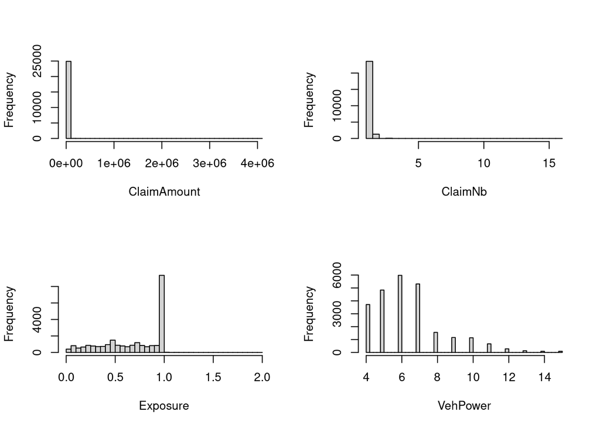

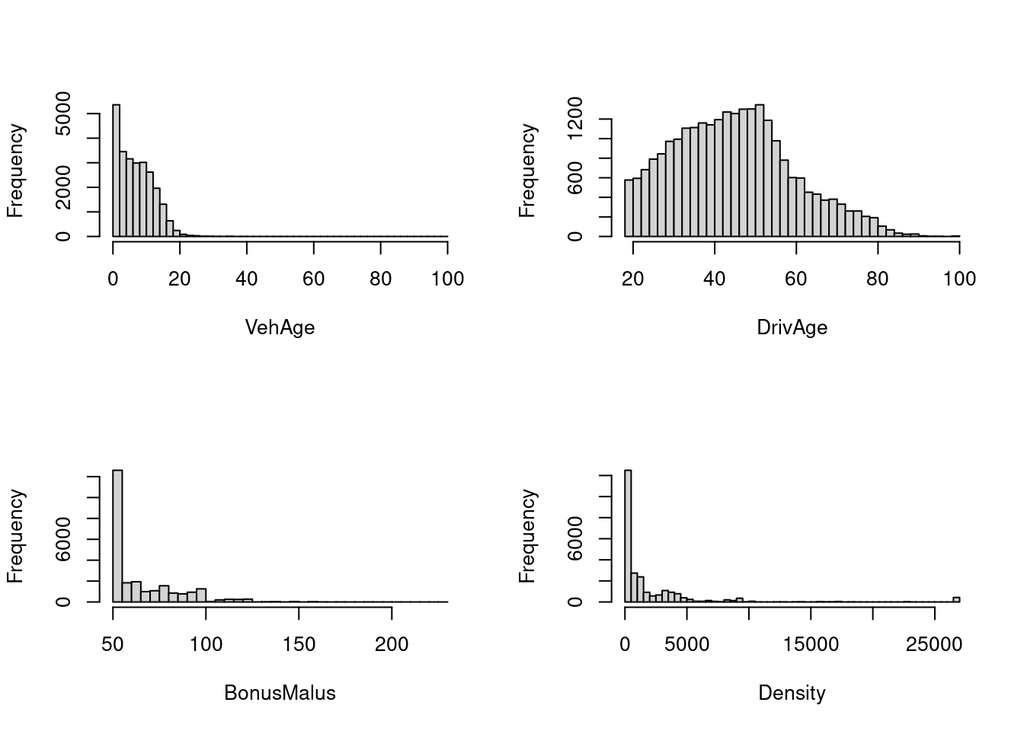

```r
# Plotting histograms for numerical data
numeric_data_freq <- c("ClaimAmount", "ClaimNb", "Exposure", "VehPower", "VehAge", "DrivAge", "BonusMalus", "Density")
par(mfrow = c(2, 2))
for (i in numeric_data_freq) {
  hist(data_sev_agg_clinfo[[i]], main = NULL, xlab = i, breaks = 40)
}
```

```r
# Creating tables for categorical data
categorical_data_freq <- c("Area", "VehBrand", "VehGas", "Region")
for (i in categorical_data_freq) {
  print(paste0("Tables for ", i))
  print("Frequency table:")
  freq_table <- table(data_sev_agg_clinfo[[i]])
  print(freq_table)
  print("Percentage table:")
  print(round(prop.table(freq_table) * 100, 2))
}
```

```
[1] "Tables for Area"
[1] "Frequency table:"

   A    B    C    D    E    F
3237 2524 6730 6042 5697  713
[1] "Percentage table:"

    A     B     C     D     E     F
12.98 10.12 26.98 24.22 22.84  2.86
[1] "Tables for VehBrand"
[1] "Frequency table:"

  B1  B10  B11  B12  B13  B14   B2   B3   B4   B5   B6
6509  732  626 3826  511  127 6486 2304 1053 1580 1189
[1] "Percentage table:"

   B1   B10   B11   B12   B13   B14    B2    B3    B4    B5    B6
26.10  2.93  2.51 15.34  2.05  0.51 26.00  9.24  4.22  6.33  4.77
[1] "Tables for VehGas"
[1] "Frequency table:"

 Diesel Regular
  12700   12243
[1] "Percentage table:"

 Diesel Regular
  50.92   49.08
[1] "Tables for Region"
[1] "Frequency table:"

 R11  R21  R22  R23  R24  R25  R26  R31  R41  R42  R43  R52  R53  R54  R72  R73
2392   70  302  209 6262  429  328  872  452   83   36 1498 1793  765  985  350
 R74  R82  R83  R91  R93  R94
 184 4002  135  934 2753  109
[1] "Percentage table:"

  R11   R21   R22   R23   R24   R25   R26   R31   R41   R42   R43   R52   R53
 9.59  0.28  1.21  0.84 25.11  1.72  1.31  3.50  1.81  0.33  0.14  6.01  7.19
  R54   R72   R73   R74   R82   R83   R91   R93   R94
 3.07  3.95  1.40  0.74 16.04  0.54  3.74 11.04  0.44
```

Most numerical variables are not normally distributed. We might need to normalize them. Observing the small classes for `VehBrand` and `Region` we might want to merge these classes to avoid overfitting.

# Outlier removal

## Number of claims

```r
# take a look at the observations with the larges number of claims.
head(data_sev_agg_clinfo[order(data_sev_agg_clinfo$ClaimNb, decreasing = TRUE), ], n = 20)
```

```
        IDpol ClaimNb Exposure Area VehPower VehAge DrivAge BonusMalus VehBrand
14313 2241683      16     0.33    D        4     12      52         50       B1
19465 3253234      11     0.08    D        4     13      53         50       B1
19474 3254353      11     0.07    D        4     13      53         50       B1
14329 2248174       9     0.08    D        4     12      52         50       B1
14302 2239279       8     0.41    D        4     12      52         50       B1
14095 2216294       6     0.33    D        4     12      52         50       B1
2397    93954       5     1.00    E        7      9      67         50       B2
14889 2277762       5     0.08    D        4     12      52         50       B1
1147    54009       4     0.56    A        4      4      46         50       B4
15245 3016883       4     0.27    E        5      9      23         90       B3
19744 4031494       4     0.10    E        4      1      31         85      B12
24258 6006882       4     0.49    E        6      6      53         50      B12
24489 6059824       4     0.57    D        5      2      48         64      B12
985     48174       3     0.51    C        8      4      22        106       B2
```

[output cut: 27 more lines]

```r
# remove the observations with more than 5 claims
data_sev_agg_clinfo <- data_sev_agg_clinfo[data_sev_agg_clinfo$ClaimNb < 5, ]
```

We see that the observations with more than 5 claims stem probably from the same person. We remove these observations. The idea of this removal stems from M. Wüthrich and Merz (2023), https://doi.org/10.1007/978-3-031-12409-9_13

## Claim amount

```r
# take a look at the observations with the largest claim amount
head(data_sev_agg_clinfo[order(data_sev_agg_clinfo$ClaimAmount, decreasing = TRUE), ], n = 20)
```

```
        IDpol ClaimNb Exposure Area VehPower VehAge DrivAge BonusMalus VehBrand
7488  1120377       1     0.22    B        9     13      19        100       B2
2843   110846       2     0.43    C        6     13      20        100       B1
12730 2141337       1     0.32    D        4     14      18        100       B2
17084 3122016       1     0.91    E        7      7      40         63      B11
9765  2008127       3     0.36    D        4      2      57         50       B4
15354 3025890       2     0.09    A        7      1      36         50      B12
7358  1117644       1     0.85    C        7      1      21         90       B3
3801   158309       1     0.75    A        6      3      46         50       B1
16182 3075820       1     0.58    E        7     18      78         50      B10
17789 3150210       1     0.48    D        6      4      61         54       B3
22584 4169019       1     0.13    E        4     14      27        100       B4
6657  1096763       1     1.00    C        4     12      27         90       B2
13822 2206511       1     0.42    B        7      5      31         51       B2
22169 4159792       1     0.36    C        5      9      72         50       B1
```

[output cut: 27 more lines]

```r
# take a look at the observations with the smallest claim amount
tail(data_sev_agg_clinfo[order(data_sev_agg_clinfo$ClaimAmount, decreasing = TRUE), ], n = 20)
```

```
        IDpol ClaimNb Exposure Area VehPower VehAge DrivAge BonusMalus VehBrand
8600  1167638       1     1.00    C        7      5      49         60       B1
16819 3108440       1     0.76    C        6      5      46         50       B3
4267   175384       1     1.00    D        4      1      75         50       B1
12409 2127960       1     1.00    E        6      4      41         50       B2
1414    62913       1     1.00    D        6      7      45        118       B1
4833  1024103       1     1.00    D       11     11      52         50       B2
7668  1123901       1     0.32    E        4     22      31         80       B1
4197   172606       1     1.00    E       13     13      61         50      B10
18620 3174485       1     0.11    D       15      9      21         95       B2
18838 3186703       1     0.90    B        7     11      42         50       B1
22114 4158800       1     1.00    D        7     15      41         80       B2
21768 4152167       1     1.00    C        5      3      67         50       B2
13396 2188088       1     1.00    A       10      4      57         50      B12
23329 5005770       1     0.38    E        6     10      42         68      B13
```

[output cut: 27 more lines]

We do not see any observations in the claim amount stemming from a single suspicious person. Still, the one claim above € 4M and the two claims above € 1M seem like outliers. They will be winsorized later.

# Build independent variable

```r
data_sev_agg_clinfo$ClaimAmount_expected <- data_sev_agg_clinfo$ClaimAmount / data_sev_agg_clinfo$Exposure
```

# Winsorizing

Since car insurances last usually one year, we winsorize the exposure to 1.

```r
data_sev_agg_clinfo$Exposure <- ifelse(data_sev_agg_clinfo$Exposure > 1, 1, data_sev_agg_clinfo$Exposure)
```

In the insurance context, large claims are usually handled by winsorizing Therefore, we take a look at the quantiles.

```r
quantile(data_sev_agg_clinfo$ClaimAmount_expected, probs = c(0, 0.005, 0.01, 0.025, 0.05, 0.95, 0.975, 0.99, 0.995, 1))
```

```
          0%         0.5%           1%         2.5%           5%          95%
1.000000e+00 3.249357e+01 5.326360e+01 7.610640e+01 1.165587e+02 1.880341e+04
       97.5%          99%        99.5%         100%
3.800697e+04 1.099129e+05 2.207547e+05 1.852455e+07
```

```r
# winsorize 0.5 % from above and below
data_sev_agg_clinfo$ClaimAmount_expected <- Winsorize(data_sev_agg_clinfo$ClaimAmount_expected, val = quantile(data_sev_agg_clinfo$ClaimAmount_expected, probs = c(0.025, 0.975), na.rm = FALSE))
```

We winsorize 5 % of the claims, i.e., 2.5 percent from above and 2.5 percent from below, since the gap between the 99 % quantile and the 97.5 % quantile is far larger than the gap between the 97.5 % and the 95 % quantile.

Potentially, we should also winsorize the vehicle age bonus-malus level. For consistency reasons, we winsorize all numerical variables.

```r
for (i in c("VehPower", "VehAge", "DrivAge", "BonusMalus", "Density")) {
  print(paste0("Quantiles for ", i, ":"))
  print(quantile(data_sev_agg_clinfo[[i]], probs = c(0, 0.005, 0.01, 0.025, 0.05, 0.95, 0.975, 0.99, 0.995, 1)))
  # winsorize 0.5 % from above and below
  data_sev_agg_clinfo[[i]] <- Winsorize(data_sev_agg_clinfo[[i]], val = quantile(data_sev_agg_clinfo[[i]], probs = c(0.025, 0.975), na.rm = FALSE))
}
```

```
[1] "Quantiles for VehPower:"
   0%  0.5%    1%  2.5%    5%   95% 97.5%   99% 99.5%  100%
    4     4     4     4     4    11    11    13    14    15
[1] "Quantiles for VehAge:"
   0%  0.5%    1%  2.5%    5%   95% 97.5%   99% 99.5%  100%
    0     0     0     0     1    16    18    20    22    99
[1] "Quantiles for DrivAge:"
   0%  0.5%    1%  2.5%    5%   95% 97.5%   99% 99.5%  100%
   18    19    19    21    23    72    77    81    83    99
[1] "Quantiles for BonusMalus:"
   0%  0.5%    1%  2.5%    5%   95% 97.5%   99% 99.5%  100%
   50    50    50    50    50   100   118   125   132   228
[1] "Quantiles for Density:"
   0%  0.5%    1%  2.5%    5%   95% 97.5%   99% 99.5%  100%
    2     8    10    15    24  8455 12750 27000 27000 27000
```

# Correlation Analysis for numerical variables

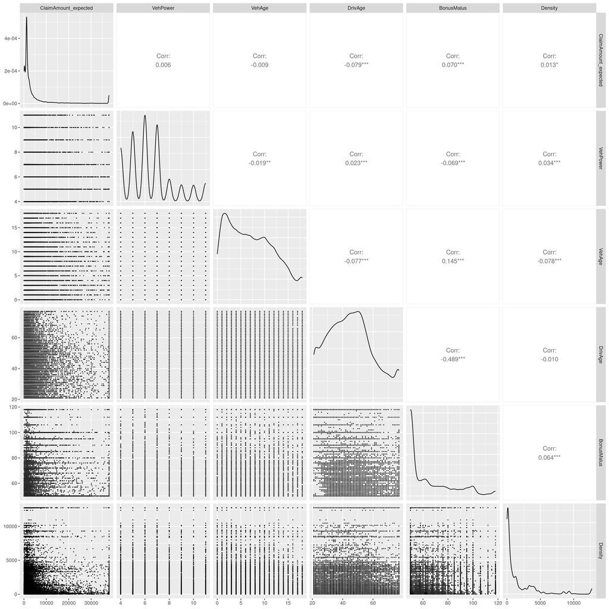

```r
ggpairs(data_sev_agg_clinfo[, c("ClaimAmount_expected", "VehPower", "VehAge", "DrivAge", "BonusMalus", "Density")], progress = FALSE, lower = list(continuous = wrap("points", size = 0.1)))
```

The largest (negative) correlation seems to be between the driver’s age and the bonus-malus level. Regarding our independent variable, the driver age and the bonus-malus level correlate negatively and positively respectively.

# Box plot for categorical variables

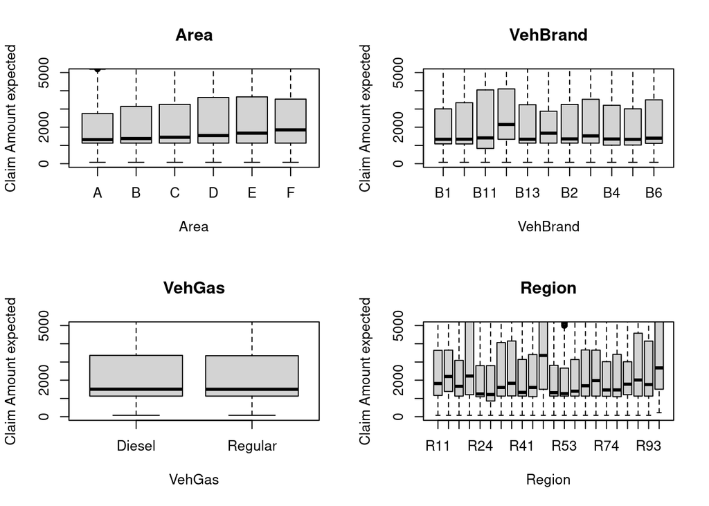

```r
par(mfrow = c(2, 2))
for (i in categorical_data_freq) {
  # cut y axis at 5000 for visualization purposes
  boxplot(data_sev_agg_clinfo$ClaimAmount_expected ~ data_sev_agg_clinfo[[i]], ylim = c(0, 5000), main = i, xlab = i, ylab = "Claim Amount expected")
}
```

The box plots show that some characteristics of area, vehicle brand, and region have a higher impact on the expected claim amount than the others. The two types of vehicle gas do not seem to have large differences in the expected claim amount.

# Save data

```r
# Remove unnecessary columns
data_sev_agg_clinfo <- data_sev_agg_clinfo %>% select(-c(ClaimAmount, ClaimNb, IDpol, Exposure))
# Save data as RDS
saveRDS(data_sev_agg_clinfo, file = here::here("data", "edit", "data_sev_agg_clinfo.rds"))
```